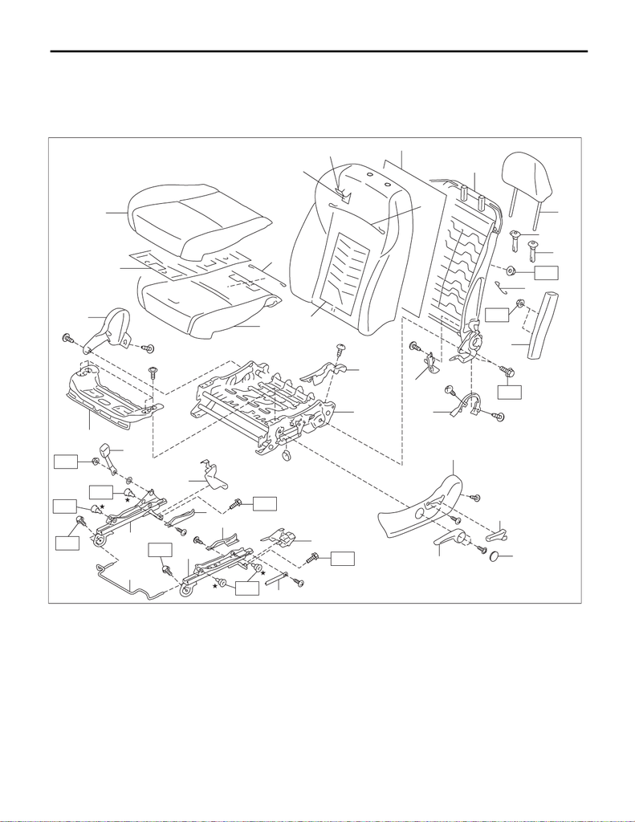

SE-2

General Description

SEATS

1. General Description

A: COMPONENT

1. FRONT SEAT

• Manual seat LH

SE-01674

T3

(1)

(2)

(3)

(4)

(5)

(6)

(7)

(8)

(9)

(10)

(11)

(14)

(15)

(16)

(17)

(18)

(20)

(13)

(19)

(21)

(22)

(24)

(23)

(25)

(26)

(27)

(28)

(32)

(31)

(33)

(29)

(12)

T5

T5

T5

T5

T2

T2

T2

T1

T1

T4

(30)

[figure not shown]

SE-3

General Description

SEATS

(1) Pad ASSY - front seat backrest (15) Cover - hinge front seat OUT (29) Pad ASSY - front seat cushion

(2) Cover COMPL - front backrest (16) Lever - reclining (30) Heater unit - front seat backrest

(3) Cover - silencer front seat back-

rest

(17) Cap - lifter lever (31) Wire set - front seat cushion

(4) Wire set - front seat backrest (18) Knob - lifter (32) Heater unit - front seat cushion

(5) Frame ASSY - front backrest (19) Cover - bolt rear OUT (33) Cover - front cushion

(6) Headrest ASSY - front (20) Cover - slide rail OUT

(7) Bushing - lock headrest (21) Cover - slide rail OUT Tightening torque: N·m (kgf-m, ft-lb)

(8) Bushing - free headrest (22) Slide rail ASSY - OUT T1: 6 (0.6, 4.4)

(9) Hook - backrest front (23) Lever - towel bar T2: 15 (1.5, 11.1)

(10) Side airbag module LH (24) Slide rail ASSY - INN T3: 38 (3.9, 28.0)

(11) Cover - inner front (25) Cover - bolt rear INN T4: 52 (5.3, 38.4)

(12) Cover - frame front cushion (26) Seat belt inner - front T5: 53 (5.4, 39.1)

(13) Frame ASSY - front cushion (27) Panel - front seat

(14) Cover - hinge base front seat (28) Cover - hinge front seat INN

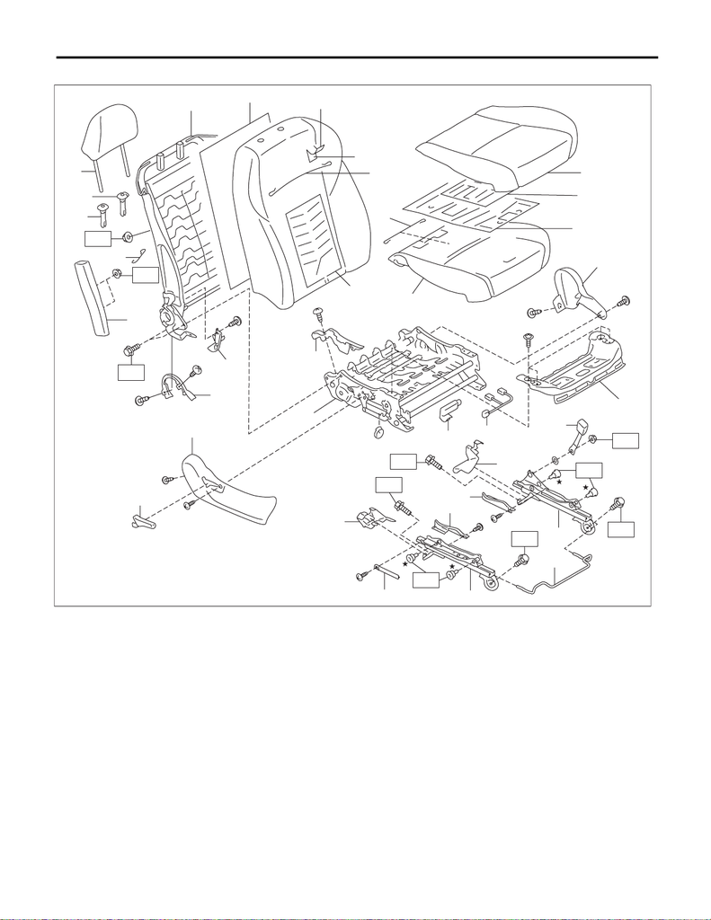

SE-4

General Description

SEATS

• Manual seat RH

SE-01675

(1)

(2)

(3)

(4)

(5)

(9)

(10)

(6)

(11)

(12)

(13)

(14)

(25)

(26)

(24)

(23)

(22)

(16)

(15)

(18)

(19)

(27)

(28)

(29)

(30)

(31)

(32)

(33)

(34)

(7)

(8)

T1

T1

T2

T5

T2

T3

T5

(21)

(20)

T5

T5

T4

(35)

(17)

[figure not shown]

SE-5

General Description

SEATS

(1) Frame ASSY - front backrest (15) Slide rail ASSY - INN (29) Cover - hinge base front seat

(2) Cover - silencer front seat back-

rest

(16) Lever - towel bar (30) Cover - inner front

(3) Cover COMPL - front backrest (17) Slide rail ASSY - OUT (31) Side airbag module RH

(4) Pad ASSY - front seat backrest (18) Cover - slide rail OUT (32) Hook - backrest front

(5) Wire set - front seat backrest (19) Cover - bolt rear OUT (33) Bushing - lock headrest

(6) Wire set - front seat cushion (20) Cover - slide rail OUT (34) Bushing - free headrest

(7) Heater unit - front seat backrest (21) Cover - slide rail INN (35) Headrest ASSY - front

(8) Pad ASSY - front seat cushion (22) Cover - bolt rear INN

(9) Cover - front cushion (23) Harness - occupant detection sen-

sor

Tightening torque: N·m (kgf-m, ft-lb)

(10) Heater unit - front cushion (24) Control unit - occupant detection

sensor

T1: 6 (0.6, 4.4)

(11) Occupant detection sensor (25) Cover - frame front seat cushion T2: 15 (1.5, 11.1)

(12) Cover - hinge front seat INN (26) Frame ASSY - front seat cushion T3: 38 (3.9, 28.0)

(13) Panel - front seat (27) Lever - reclining T4: 52 (5.3, 38.4)

(14) Seat belt inner - front (28) Cover - hinge front seat OUT T5: 53 (5.4, 39.1)

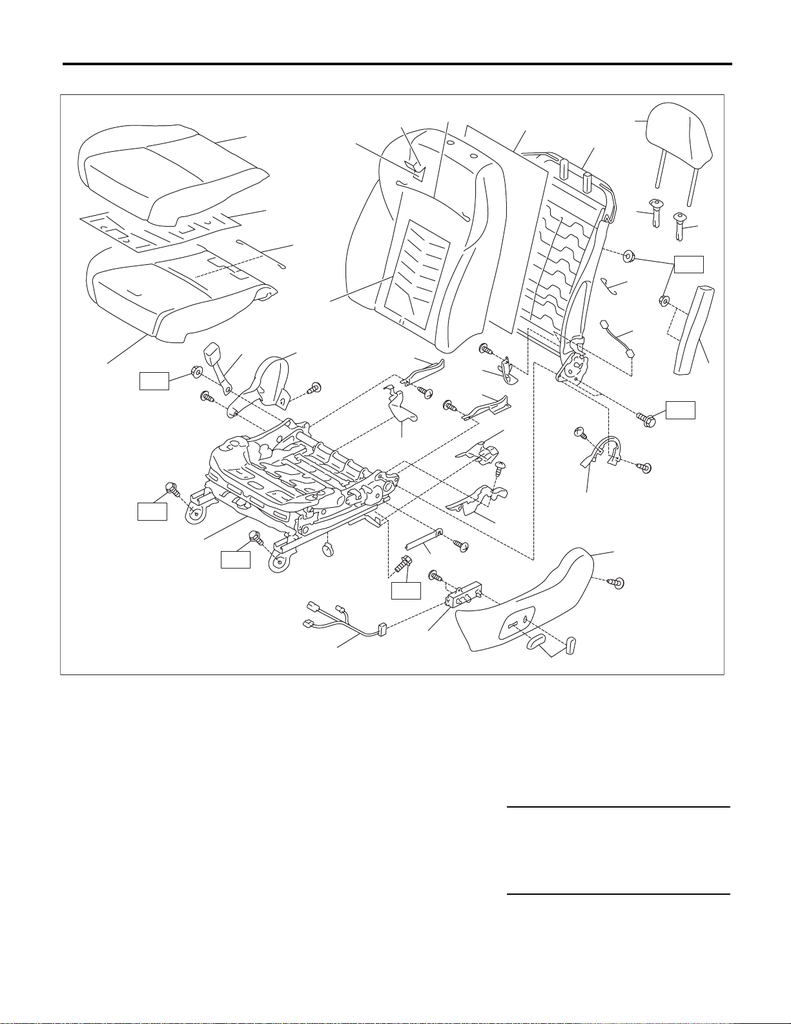

SE-6

General Description

SEATS

• Power seat

(1) Pad ASSY - front seat backrest (14) Knob - power seat (27) Cover - hinge front seat INN

(2) Cover COMPL - front backrest (15) Switch ASSY - power seat (28) Heater unit - front seat backrest

(3) Wire set - front seat backrest (16) Harness ASSY - power seat (29) Wire set - front seat cushion

(4) Cover - silencer front seat back-

rest

(17) Cover - slide rail OUT (30) Heater unit - front cushion

(5) Frame ASSY - front backrest (18) Cover - frame front seat cushion (31) Cover - front cushion

(6) Headrest ASSY - front (19) Cover - bolt rear OUT

(7) Bushing - lock headrest (20) Cover - slide rail OUT Tightening torque: N·m (kgf-m, ft-lb)

(8) Bushing - free headrest (21) Cover - inner front T1: 6 (0.6, 4.4)

(9) Hook - backrest front (22) Cover - slide rail INN T2: 38 (3.9, 28.0)

(10) Harness ASSY - power seat (23) Cover - bolt rear INN T3: 52 (5.3, 38.4)

(11) Side airbag module (24) Frame ASSY - front cushion T4: 53 (5.4, 39.1)

(12) Cover - hinge base front seat (25) Pad ASSY - front seat cushion

(13) Cover - hinge front seat OUT (26) Seat belt inner - front

T2

(19)

(23)

T4

T4

(1)

(2)

(5)

(6)

(7)

(11)

(9)

(10)

(12)

(13)

(14)

(15)

(16)

(18)

(20)

(22)

(27)

(26)

(24)

(25)

(29)

(30)

(31)

(21)

(28)

T1

T3

(17)

SE-01676

(8)

T4

(4)

(3)

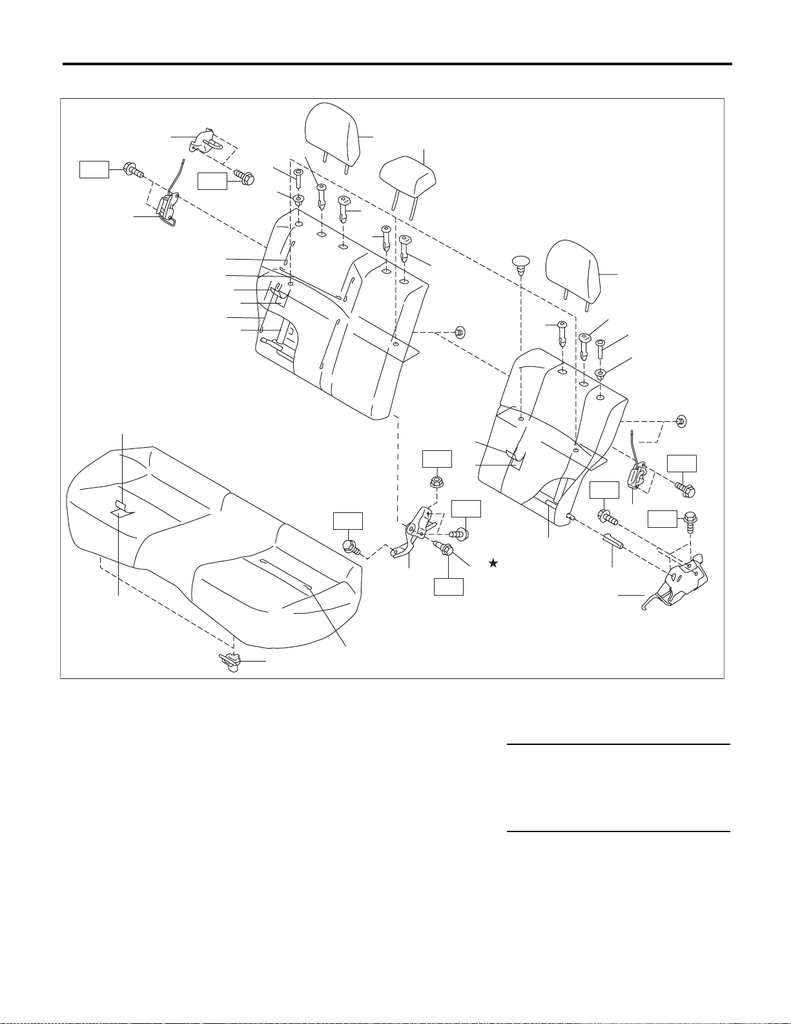

SE-7

General Description

SEATS

2. REAR SEAT

(1) Striker - backrest rear RH (12) Flange bolt (23) Hook - seat cushion rear

(2) Knob - backrest rear (13) Hinge ASSY - backrest center (24) Wire set - rear cushion

(3) Knob - guide (14) Pad ASSY - rear seat backrest LH

(4) Bushing - headrest (15) Cover COMPL - rear backrest LH Tightening torque: N·m (kgf-m, ft-lb)

(5) Bushing - lock ASSY (16) Frame ASSY - rear backrest RH T1: 22.5 (2.3, 16.6)

(6) Headrest ASSY - rear backrest (17) Pad ASSY - rear seat backrest RH T2: 24.5 (2.5, 18.1)

(7) Headrest ASSY - rear center (18) Cover COMPL - rear backrest RH T3: 28.9 (2.9, 21.3)

(8) Lock ASSY - backrest rear LH (19) Wire set - rear backrest T4: 33 (3.4, 24.3)

(9) Bushing - backrest hinge (20) Lock ASSY - backrest rear RH

(10) Hinge ASSY - rear backrest (21) Cover - rear cushion

(11) Frame ASSY - rear backrest LH (22) Pad and frame ASSY - rear cush-

ion

SE-01699

(1)

(21)

(20)

(19)

(18)

(17)

(14)

(7)

(4)

(5)

(6)

(4)

(5)

(8)

(9)

(10)

(11)

(16)

(15)

(12)

(24)

(23)

(22)

(13)

T1

T2

T3

T4

T4

T4

T1

(6)

(4)

(5)

(2)

(3)

(2)

(3)

T4

T4

(19)

(19)

[figure not shown]

SE-8

General Description

SEATS

B: CAUTION

When removing the front seat from the vehicle, refer to “CAUTION” of “General Description” in “AIRBAG

SYSTEM” section. <Ref. to AB-9, CAUTION, General Description.>

C: PREPARATION TOOL

1. GENERAL TOOL

TOOL NAME REMARKS

Long nose plier Used for removing the hog ring.

Hog ring pliers Used for installing the hog ring.

Circuit tester Used for measuring resistance and voltage.